# Experience vs. description based decision-making project: DDM RL joint modeling

# Important note

This RL model only takes fractal rewards into account and it does so for both fractals with the same weight. The overall trial reward is not included anywhere. THere is also no bias about learning e.g. faster for chosen fractal compared to unchosen fractal.

Pre-checks to determine whether either of these factors warrant their own RL model:

**Overall trial reward**:  
What behavioral effect could/should it have?  
It shouldn’t affect learning, fractal rewards only depend on their own probabilities.  
It shouldn’t affect choice separate from all the other components of EV, QV and their weighted sum based on probFractalDraw because it is a direct function of those components.  
It might affect perseverance, ie choosing the same side if a reward was received for the previous trial.

**Bias in learning** What sort of behavioral effect might this have?

# DDRL model 1c

Parameters: d, sigma, alpha, delta  
Single drift rate for bundle value  
Single learning rate for both fractals  
Single probability distortion parameter distorting true relevance of fractals

## Parameter recovery

True datasets created with combinations of `true_ds = c(.06 , .5)`, `true_sigmas = c(.08, .3)`, `true_alphas = c(.1, .5)`, `true_deltas = c(.1, 1, 3)`

### Results

```r
source(paste0(helpers_path,'optimPostProcess/par_recovery_report.R'))
cpueaters_path = '/Users/zeynepenkavi/CpuEaters/DescribedVsLearned_beh/analysis/helpers/'
```

```r
optim_out_path = paste0(cpueaters_path, 'ddrlModels/cluster_scripts/optim_out/')
true_pars_path = paste0(helpers_path, 'ddrlModels/cluster_scripts/test_data/')
param_dict = data.frame(Param1="d", Param2="sigma", Param3="alpha", Param4="delta", Result="nll")

model = "model1c"
data_suffix = "sim_single_sub_data"

data_nums = c(1:24)

# Note this takes a little bit
diff_pct_data = data.frame()

for(i in 1:length(data_nums)){
  cur_data_num = data_nums[i]
  cur_sim_type = "sim1"
  cur_out = par_recovery_report(model_ = model, data_ = paste0(data_suffix,cur_data_num), optim_out_path_= paste0(optim_out_path, cur_sim_type, '/'), true_pars_path_ = true_pars_path, diff_pct_plots_ = TRUE, param_dict_ = param_dict)$diff_pct_data
  cur_out$sim_type = cur_sim_type
  cur_out$data_num = as.character(cur_data_num)
  diff_pct_data = rbind.all.columns(diff_pct_data, cur_out)
}
```

```r
plot_heatmaps = function(x_par = "d", y_par = "sigma", fill_par = "alpha", row_par = "delta"){

  diff_pct_data = diff_pct_data %>%
    mutate(true_val = as.factor(true_val))

  tmp1 = diff_pct_data %>%
    filter(key == x_par) %>%
    select(key, true_val, data_num) %>%
    spread(key, true_val)

  tmp2 = diff_pct_data %>%
    filter(key == y_par) %>%
    select(key, true_val, data_num) %>%
    spread(key, true_val)

  tmp3 = diff_pct_data %>%
    filter(key == row_par) %>%
    select(key, true_val, data_num) %>%
    mutate(row_par = paste0(key, "=", true_val)) %>%
    select(data_num, row_par)

  tmp4 = diff_pct_data %>%
    filter(key == fill_par) %>%
    select(key, true_val, data_num) %>%
    mutate(true_val = paste0(key, "=", true_val)) %>%
    select(-key)

  tmp5 = diff_pct_data %>%
    filter(key == fill_par) %>%
    select(key, median_diff, data_num) %>%
    spread(key, median_diff) %>%
    rename(median_diff = fill_par)

  p = tmp1 %>%
    left_join(tmp2, by="data_num") %>%
    left_join(tmp3, by="data_num") %>%
    left_join(tmp4, by="data_num") %>%
    left_join(tmp5, by="data_num") %>%
    mutate(median_diff_clipped = ifelse(median_diff>100, 101, median_diff)) %>%
    ggplot(aes_string(x=x_par, y=y_par))+
    geom_tile(aes(fill=median_diff_clipped))+
    facet_grid(row_par~true_val)+
    theme(legend.position = "bottom", legend.margin=margin(0,0,0,0), legend.box.margin=margin(-10,-10,0,-10))+
    labs(x=x_par, y=y_par, fill=paste0("Median % difference between true and estimated ", fill_par))

  return(p)
}
```

```r
fig_fn = 'ddmrl_recovery_sim1'
```

How bad is recovery for each parameter as a function of the other parameters?

- Small alpha is not recovered at all. Large alpha is better but still pretty bad in general.
- Adding alpha to the model affected the recoverability of delta. Before delta was more recoverable for medium and large d and sigmas but now delta <= 1 is not recovered.
- d and especially sigma are still relatively robust.

```r
p1 = plot_heatmaps(x_par = "d", y_par = "sigma", fill_par = "alpha", row_par = "delta")
p2 = plot_heatmaps(x_par = "d", y_par = "sigma", row_par = "alpha", fill_par = "delta")
p3 = plot_heatmaps(fill_par = "d", y_par = "sigma", row_par = "alpha", x_par = "delta")
p4 = plot_heatmaps(x_par = "d", fill_par = "sigma", row_par = "alpha", y_par = "delta")
```

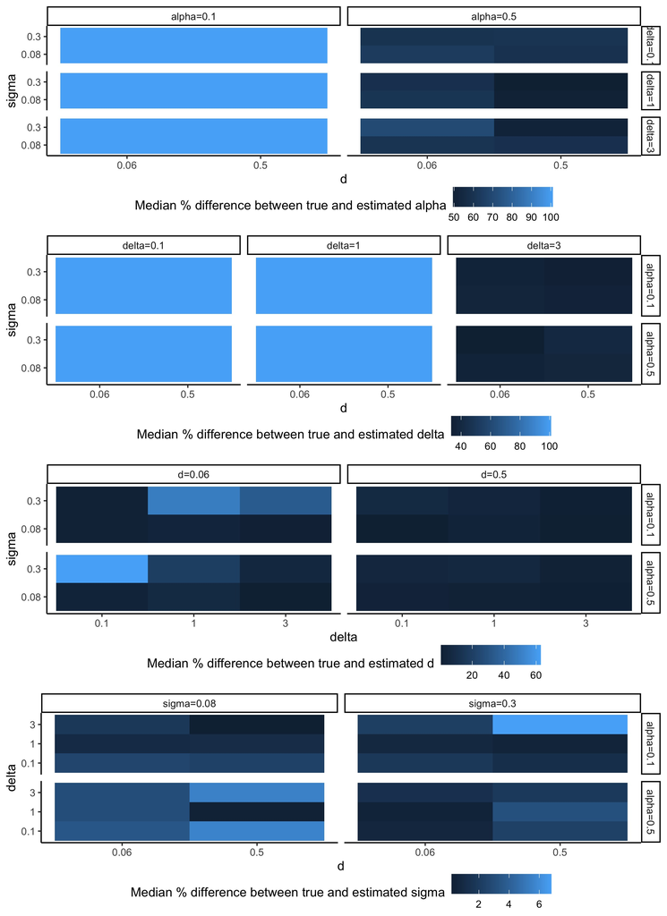

```r
g = arrangeGrob(grobs=list(p1, p2, p3, p4), nrow=4)
ggsave(file=paste0(fig_out_path, fig_fn, '_diff_pct_heatmaps.jpg'), g, height = 11, width=8, units="in")
ggsave(file=paste0(fig_out_path, fig_fn, '_diff_pct_heatmaps.pdf'), g, height = 11, width=8, units="in")
```